# Fraud Detection

Jael Tegulwa

2022-11-03

## Data Preprocessing

Libraries and import data

```r
library(dplyr)
```

```r
library(ggplot2)
transactions<-read.csv("fraud.csv", header=TRUE, sep=",")
```

View the data

```r
head(transactions)
```

```
##   step     type   amount    nameOrig oldbalanceOrg newbalanceOrig    nameDest
## 1    1  PAYMENT  9839.64 C1231006815        170136      160296.36 M1979787155
## 2    1  PAYMENT  1864.28 C1666544295         21249       19384.72 M2044282225
## 3    1 TRANSFER   181.00 C1305486145           181           0.00  C553264065
## 4    1 CASH_OUT   181.00  C840083671           181           0.00   C38997010
## 5    1  PAYMENT 11668.14 C2048537720         41554       29885.86 M1230701703
## 6    1  PAYMENT  7817.71   C90045638         53860       46042.29  M573487274
##   oldbalanceDest newbalanceDest isFraud isFlaggedFraud
## 1              0              0       0              0
## 2              0              0       0              0
## 3              0              0       1              0
## 4          21182              0       1              0
## 5              0              0       0              0
## 6              0              0       0              0
```

```r
dim(transactions)
```

```
## [1] 6362620      11
```

The datset contains 11 attributes and 6,362,620 transaction observations

Let’s view a summary of the data.

```r
summary(transactions)
```

```
##       step           type               amount           nameOrig
##  Min.   :  1.0   Length:6362620     Min.   :       0   Length:6362620
##  1st Qu.:156.0   Class :character   1st Qu.:   13390   Class :character
##  Median :239.0   Mode  :character   Median :   74872   Mode  :character
##  Mean   :243.4                      Mean   :  179862
##  3rd Qu.:335.0                      3rd Qu.:  208721
##  Max.   :743.0                      Max.   :92445517
##  oldbalanceOrg      newbalanceOrig       nameDest         oldbalanceDest
##  Min.   :       0   Min.   :       0   Length:6362620     Min.   :        0
##  1st Qu.:       0   1st Qu.:       0   Class :character   1st Qu.:        0
##  Median :   14208   Median :       0   Mode  :character   Median :   132706
##  Mean   :  833883   Mean   :  855114                      Mean   :  1100702
##  3rd Qu.:  107315   3rd Qu.:  144258                      3rd Qu.:   943037
##  Max.   :59585040   Max.   :49585040                      Max.   :356015889
##  newbalanceDest         isFraud         isFlaggedFraud
##  Min.   :        0   Min.   :0.000000   Min.   :0.0e+00
##  1st Qu.:        0   1st Qu.:0.000000   1st Qu.:0.0e+00
##  Median :   214661   Median :0.000000   Median :0.0e+00
##  Mean   :  1224996   Mean   :0.001291   Mean   :2.5e-06
##  3rd Qu.:  1111909   3rd Qu.:0.000000   3rd Qu.:0.0e+00
##  Max.   :356179279   Max.   :1.000000   Max.   :1.0e+00
```

These summary statistics provide a quick overview of the data in each column, including measures of central tendency (like mean and median), measures of spread (like range and quartiles), and other relevant information. type” is a character variable, so it shows the length, class, and mode of the values in this column. “amount” is another numerical variable with similar summary statistics. “nameOrig” is a character variable, so it also displays length, class, and mode. “oldbalanceOrg” and “newbalanceOrig” are numerical variables with their summary statistics. “nameDest” is a character variable, showing length, class, and mode. “oldbalanceDest” is a numerical variable with its summary statistics. “newbalanceDest” is another numerical variable with summary statistics. “isFraud” is a binary variable (0 or 1) with its minimum, 1st quartile, median, mean, 3rd quartile, and maximum values. “isFlaggedFraud” is a binary variable (0 or 1) with its minimum, 1st quartile, median, mean, 3rd quartile, and maximum values.

## Exploratory Data Analysis

## How many transactions are fraudulent?

Using the isFraud variable, number of fraud vs not fraud transactions

```r
fraud_count<- transactions %>% count(isFraud)
print(fraud_count)
```

```
##   isFraud       n
## 1       0 6354407
## 2       1    8213
```

## Visualizations of fraud frequency

Lets visualize this through a frequency plot

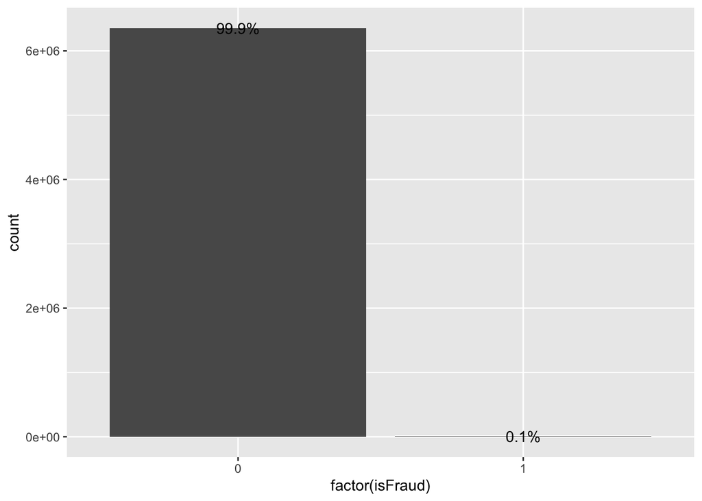

```r
g <- ggplot(transactions, aes(x = factor(isFraud)))
g + geom_bar() +
  geom_text(stat = 'count', aes(label = scales::percent((..count..) / sum(..count..), accuracy = 0.1)))
```

The dataset exhibits a significant imbalance, with fraudulent transactions accounting for a mere 0.1% of the total data. To mitigate potential model bias, it’s advisable to explore sampling techniques, such as undersampling, as a preliminary step before moving on to the modeling phase

## Transaction Types for Fraudulent cases

Ggplot showing frequency of Fraud Transactions for each Transaction type

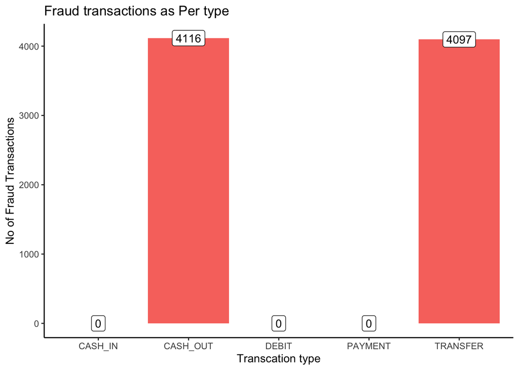

```r
Fraud_transaction_type <- transactions %>% group_by(type) %>% summarise(fraud_transactions = sum(isFraud))
ggplot(data = Fraud_transaction_type, aes(x = type,  y = fraud_transactions)) + geom_col(aes(fill = 'type'), show.legend = FALSE) + labs(title = 'Fraud transactions as Per type', x = 'Transcation type', y = 'No of Fraud Transactions') + geom_label(aes(label = fraud_transactions)) + theme_classic()
```

As observed in the plot above, fraud transactions are exclusively associated with the “CASH_OUT” and “TRANSFER” transaction types. This observation will be significant in our subsequent analysis, as we can streamline our assessment by concentrating solely on these two transaction types.

## How is the distribution of transaction amounts distributed in cases of fraud?

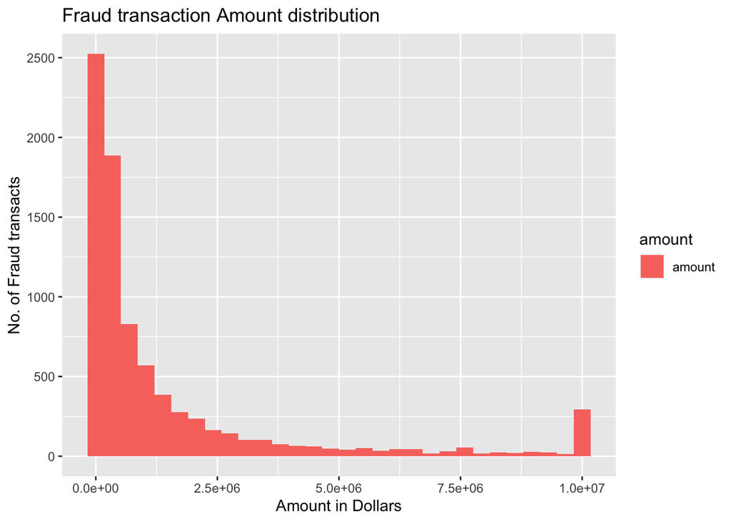

```r
ggplot(data = transactions[transactions$isFraud==1,], aes(x = amount ,  fill =amount)) + geom_histogram(bins = 30, aes(fill = 'amount')) + labs(title = 'Fraud transaction Amount distribution', y = 'No. of Fraud transacts', x = 'Amount in Dollars')
```

The distribution of transaction amounts for fraudulent cases exhibits a pronounced right skew. This indicates that the majority of fraudulent transactions involve smaller amounts.

## oldbalanceOrg vs oldbalanceDest

```r
library(gridExtra)
```

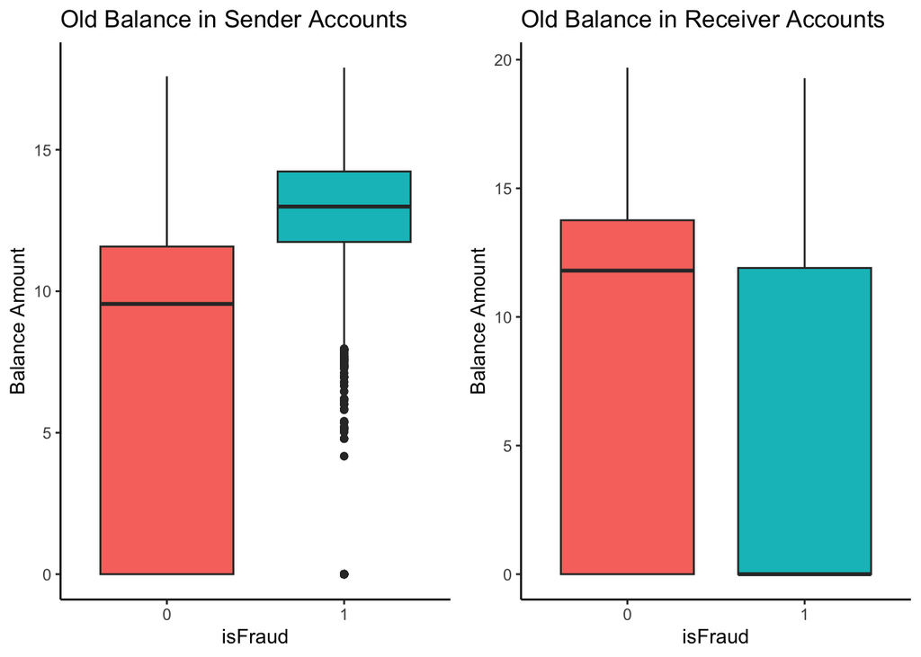

```r
p1 <- ggplot(data = transactions, aes(x = factor(isFraud), y = log1p(oldbalanceOrg), fill = factor(isFraud))) +
  geom_boxplot(show.legend = FALSE) +
  labs(title = 'Old Balance in Sender Accounts', x = 'isFraud', y = 'Balance Amount') +
  theme_classic()

p2 <- ggplot(data = transactions, aes(x = factor(isFraud), y = log1p(oldbalanceDest), fill = factor(isFraud))) +
  geom_boxplot(show.legend = FALSE) +
  labs(title = 'Old Balance in Receiver Accounts', x = 'isFraud', y = 'Balance Amount') +
  theme_classic()

grid.arrange(p1, p2, nrow = 1)
```

For most fraudulent transactions, the initial account’s old balance (where payments originate) tends to be higher than the old balances of other origin accounts, while the old balance in destination accounts is lower than the rest.

## Is there a specific time of day when fraud incidents are more prevalent?

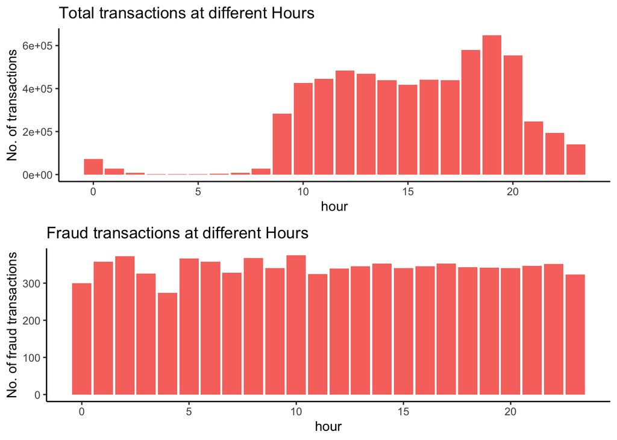

```r
# Convert Step to Hours in 24 hours format
transactions$hour <- transactions$step %% 24
#Plot newly formatted data
p5<- ggplot(data = transactions, aes(x = hour)) + geom_bar(aes(fill = 'isFraud'), show.legend = FALSE) +labs(title= 'Total transactions at different Hours', y = 'No. of transactions') + theme_classic()

p6<-ggplot(data = transactions[transactions$isFraud==1,], aes(x = hour)) + geom_bar(aes(fill = 'isFraud'), show.legend = FALSE) +labs(title= 'Fraud transactions at different Hours', y = 'No. of fraud transactions') + theme_classic()

grid.arrange(p5, p6, ncol = 1, nrow = 2)
```

## Feature Engineering and Data Cleaning

Verify if transactions occur where the transaction amount exceeds the available balance in the origin account.

```r
head(transactions[(transactions$amount > transactions$oldbalanceOrg)& (transactions$newbalanceDest > transactions$oldbalanceDest), c("amount","oldbalanceOrg", "newbalanceOrig", "oldbalanceDest", "newbalanceDest", "isFraud")], 10)
```

```
##        amount oldbalanceOrg newbalanceOrig oldbalanceDest newbalanceDest
## 11    9644.94       4465.00              0          10845      157982.12
## 16  229133.94      15325.00              0           5083       51513.44
## 25  311685.89      10835.00              0           6267     2719172.89
## 49    5346.89          0.00              0         652637     6453430.91
## 73   94253.33      25203.05              0          99773      965870.05
## 82   78766.03          0.00              0         103772      277515.05
## 84  125872.53          0.00              0         348512     3420103.09
## 85  379856.23          0.00              0         900180    19169204.93
## 86 1505626.01          0.00              0          29031     5515763.34
## 89  761507.39          0.00              0        1280036    19169204.93
##    isFraud
## 11       0
## 16       0
## 25       0
## 49       0
## 73       0
## 82       0
## 84       0
## 85       0
## 86       0
## 89       0
```

## Data Filtering

I will filter the data by transaction type to include only CASH_OUT and TRANSFER. Additionally, we can exclude the columns “nameOrig” and “nameDest” due to the excessive number of unique levels, which would make it impractical to create dummy variables for them. Moreover, we can safely remove the “step” column since it was utilized to derive the “hour” attribute.

```r
#Filtering transactions and drop irrelevant features
transactions1<- transactions %>%
  select( -one_of('step','nameOrig', 'nameDest', 'isFlaggedFraud')) %>%
  filter(type %in% c('CASH_OUT','TRANSFER'))
```

Every fraudulent transaction falls within the CASH_OUT and TRANSFER types, making other types irrelevant. Since the “step” column was used to generate the “hour” variable, we can safely discard it. Additionally, “nameOrig,” “nameDest,” and “isFlaggedFraud” serve no significant purpose and can be removed.

## Encoding Dummy variables for transaction type

```r
library(fastDummies)
transactions1 <- dummy_cols(transactions1)

transactions1$isFraud <- as.factor(transactions1$isFraud)
transactions1 <- transactions1[,-1]
transactions1<-as.data.frame(transactions1)
#summarizeColumns(transactions1)
```

## Train and Test Data

We understand that fraudulent transactions are infrequent. Given that fraudulent transactions account for only 0.1% of the dataset, employing duplication to balance the data is not the most effective approach. Instead, a more sensible strategy is to reduce the number of non-fraud cases through undersampling.

```r
set.seed(12345)
train_id <- sample(seq_len(nrow(transactions1)), size = floor(0.7*nrow(transactions1)))

train <- transactions1[train_id,]
valid <- transactions1[-train_id,]

table(train$isFraud)
```

```
##
##       0       1
## 1933579    5707
```

```r
table(valid$isFraud)
```

```
##
##      0      1
## 828617   2506
```

## Undersampling

```r
suppressMessages(library(ROSE))
set.seed(12345)
prop.table(table(train$isFraud))
```

```
##
##           0           1
## 0.997057164 0.002942836
```

```r
library(caret)
inputs <- train[,-6]
target <- train[,6]

# Downsample the data
down_train <- downSample(x = inputs, y = target)

# Calculate the proportions
proportions <- prop.table(table(down_train$Class))

# Print the proportions
print(proportions)
```

```
##
##   0   1
## 0.5 0.5
```

```r
# To see it as percentages:
percentages <- prop.table(table(down_train$Class)) * 100
print(percentages)
```

```
##
##  0  1
## 50 50
```

By applying undersampling, we achieve a balanced training dataset consisting of 5,707 observations for each class. Nevertheless, it’s important to note that our validation dataset will still maintain its imbalanced nature.

## Modeling

I will explore tree-based modeling approaches like Decision Trees and Random Forests for predicting fraudulent transactions.

## Decision tree

Using the undersampled data

Load the rpart package for decision trees Load necessary libraries

```r
library(rpart)
library(rpart.plot) # for visualizing the decision tree
```

Build the decision tree model using the balanced data ‘down_train’ and using ‘Class’ as the dependent variable

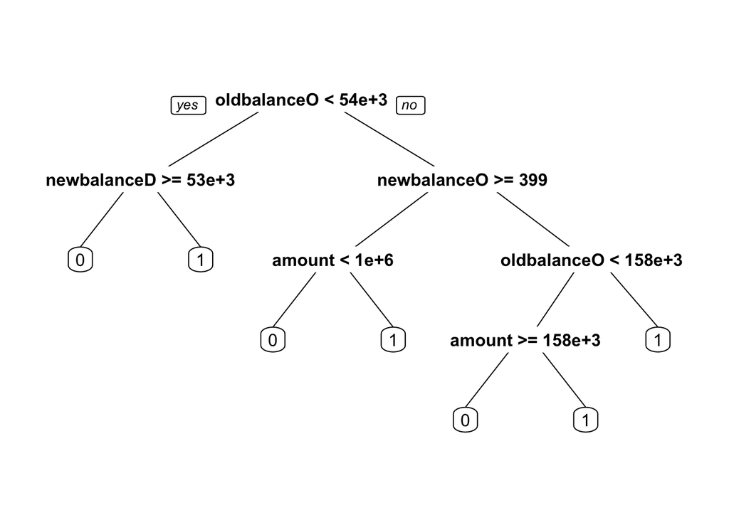

```r
model_dt <- rpart(Class ~ ., data = down_train)

# Plot the decision tree
prp(model_dt)  # prp function is from the rpart.plot package
```

```r
predict_dt <- predict(model_dt, valid, type = "class")
head(predict_dt)
```

```
##  2  6  7 10 13 14
##  1  1  0  0  0  0
## Levels: 0 1
```

```r
confusionMatrix(valid$isFraud,predict_dt)
```

```
## Confusion Matrix and Statistics
##
##           Reference
## Prediction      0      1
##          0 775545  53072
##          1    120   2386
##
##                Accuracy : 0.936
##                  95% CI : (0.9355, 0.9365)
##     No Information Rate : 0.9333
##     P-Value [Acc > NIR] : < 2.2e-16
##
##                   Kappa : 0.077
##
##  Mcnemar's Test P-Value : < 2.2e-16
##
##             Sensitivity : 0.99985
##             Specificity : 0.04302
##          Pos Pred Value : 0.93595
##          Neg Pred Value : 0.95211
##              Prevalence : 0.93327
##          Detection Rate : 0.93313
##    Detection Prevalence : 0.99698
##       Balanced Accuracy : 0.52143
##
##        'Positive' Class : 0
##
```

1 Accuracy of the model is 93.6% ## Calculate the F1 score The F1 score serves as a weighted average of Precision and Recall. We can compute this metric using the provided information because:

Recall is synonymous with Sensitivity, Precision corresponds to Positive Predictive Value.

```r
# Recall=Sensitivity
Recall_1<-0.99985
Precision_1<-0.93595

F1<-2*(Recall_1*Precision_1)/(Recall_1+Precision_1)
F1*100
```

```
## [1] 96.68453
```

```r
## [1] 96.68453
```

The F1 score for the decision tree model is 96.68% which is very good.